# 大數據分析方法

April 25, 2016

## Homework 5

- 分組名單
- 期末報告題目
- 預計分析資料
  - 資料來源
  - 資料格式
- 預計分析議題
  - 假設
  - 預計得到的結果
  - 分析結果可以解決什麼問題
- 5/2 (一) 11:59pm
- http://goo.gl/forms/8UgvNQlHVp

## 靈感！？

- [R Blogger](http://www.r-bloggers.com/)
- [Data Man的資料視覺化筆記](https://www.facebook.com/imDataMan/)
- [Data USA](http://datausa.io/)
- [Randy Olson Twitter](https://twitter.com/randal_olson)
- [Washington Post Information Graphics](http://postgraphics.tumblr.com/)
- [Washington Post | FlowingData](https://flowingdata.com/tag/washington-post/)
- [New York Times | FlowingData](https://flowingdata.com/tag/new-york-times/)

## 期中考

- 考卷
- 答案

## 演講

- 大數據在台灣金融行業的應用分享
- 講師：王葆華
- 台灣雲端行動科技公司 與 寶科資訊 負責人

## Plotting System–Base

## 探索圖範例：又是大家熟悉的NBA…

```r
#讀入SportsAnalytics package
if (!require('SportsAnalytics')){
    install.packages("SportsAnalytics")
    library(SportsAnalytics)
}
#擷取2014-2015年球季球員資料
NBA1415<-fetch_NBAPlayerStatistics("14-15")
```

## Simple Summaries of Data - 1

One dimension

- Five-number summary
- Boxplots 箱型圖
- Histograms 直方圖
- Density plot 密度圖
- Barplot 條狀圖

## Five Number Summary

```r
#總得分數
summary(NBA1415$TotalPoints)
```

```
##    Min. 1st Qu.  Median    Mean 3rd Qu.    Max.
##     0.0   141.0   420.5   500.0   772.0  2217.0
```

## Boxplot 箱型圖

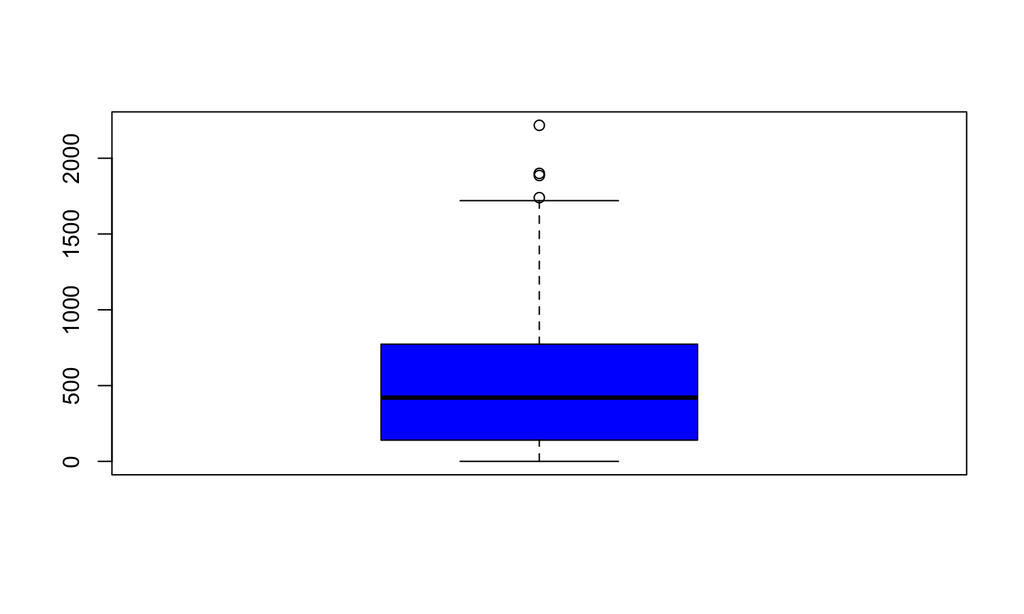

```r
#用總得分數畫箱形圖， col = "blue" 顏色藍色
boxplot(NBA1415$TotalPoints, col = "blue")
```

## Histogram 直方圖

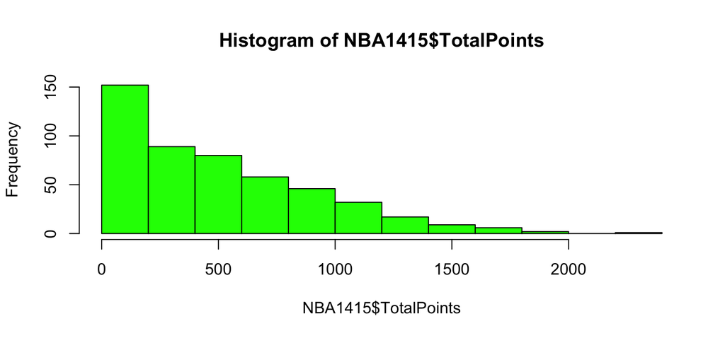

```r
#用總得分數畫直方圖， col = "green" 顏色綠色
hist(NBA1415$TotalPoints, col = "green")
```

## Histogram 直方圖

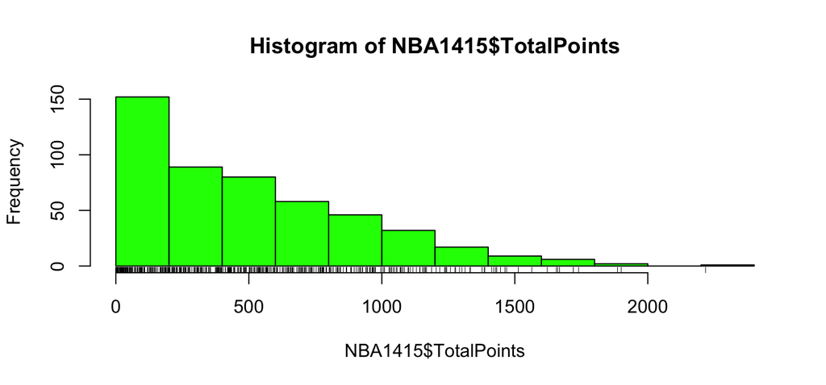

```r
hist(NBA1415$TotalPoints, col = "green")
#將總得分數實際的"值"標在直方圖下
rug(NBA1415$TotalPoints)
```

## Histogram 直方圖

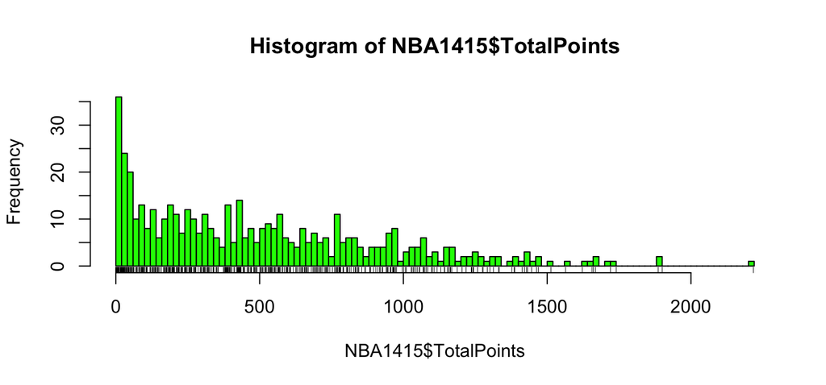

```r
#breaks = 100 表示將總得分數分為100組
hist(NBA1415$TotalPoints, col = "green", breaks = 100)
rug(NBA1415$TotalPoints)
```

## 層層疊 -1

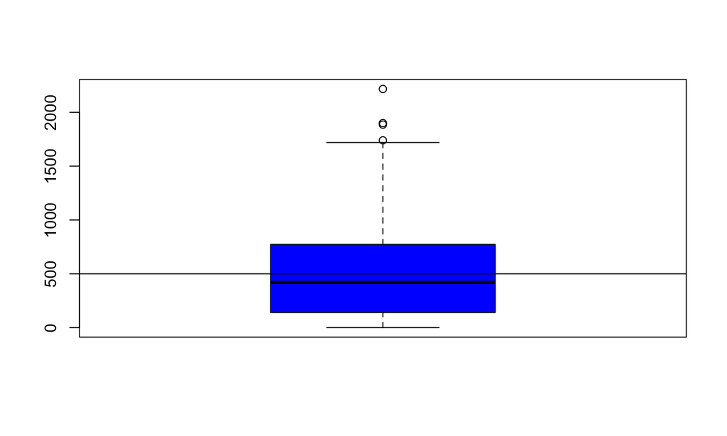

```r
boxplot(NBA1415$TotalPoints, col = "blue")
#在值等於500的地方畫一條橫線
abline(h = 500)
```

## 層層疊 -1

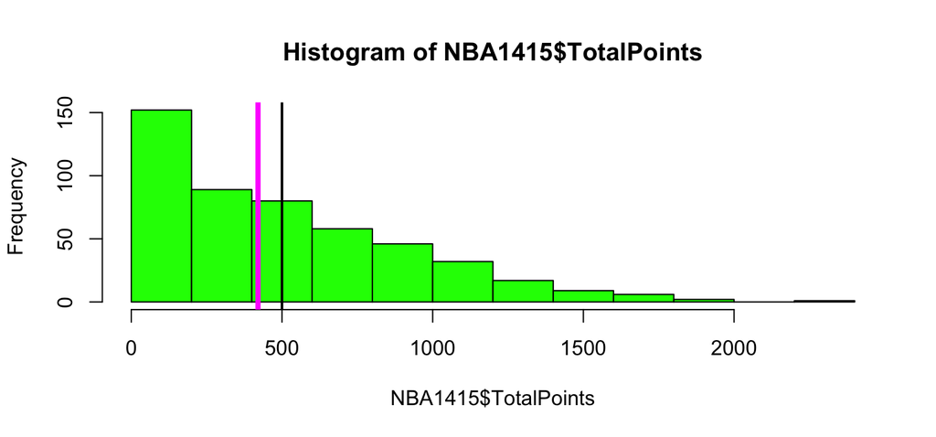

```r
hist(NBA1415$TotalPoints, col = "green")
#在值等於500的地方畫一條直線， lwd = 2: 寬度為2
abline(v = 500, lwd = 2)
#在中位數的地方畫一條直線， lwd = :4 寬度為4，顏色為magenta
abline(v = median(NBA1415$TotalPoints), col = "magenta", lwd = 4)
```

## Barplot 條狀圖

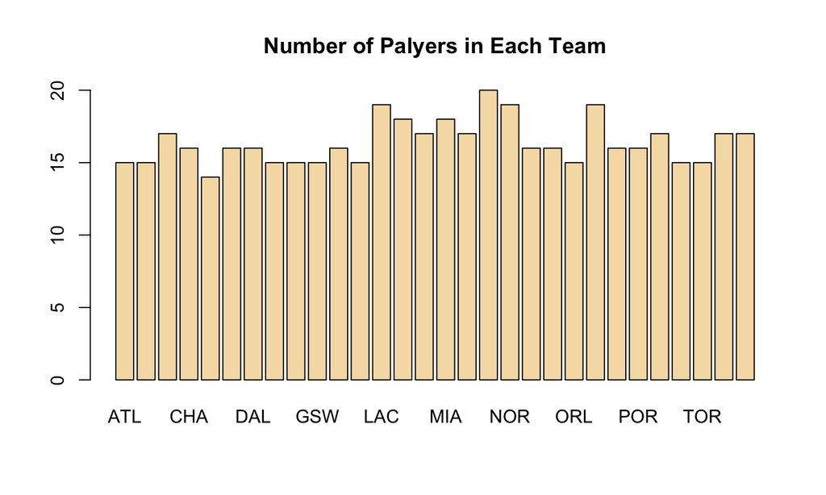

```r
#col = "wheat"小麥色，標題：main = "Number of Palyers in Each Team"
barplot(table(NBA1415$Team),
        col = "wheat", main = "Number of Palyers in Each Team")
```

## Simple Summaries of Data - 2

Two dimensions

- Multiple/overlayed 1-D plots (Lattice/ggplot2)
- Scatterplots
- Smooth scatterplots

\(> 2\) dimensions

- Overlayed/multiple 2-D plots; coplots
- Use color, size, shape to add dimensions
- Spinning plots
- Actual 3-D plots (not that useful)

## Multiple Boxplots

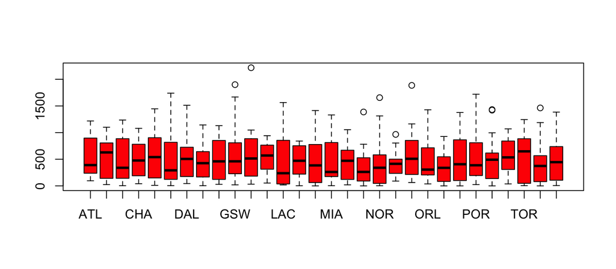

```r
#預計要做圖的'值'（TotalPoints） ~ 分組依據（Team）
boxplot(TotalPoints ~ Team, data = NBA1415, col = "red")
```

## Multiple Histograms

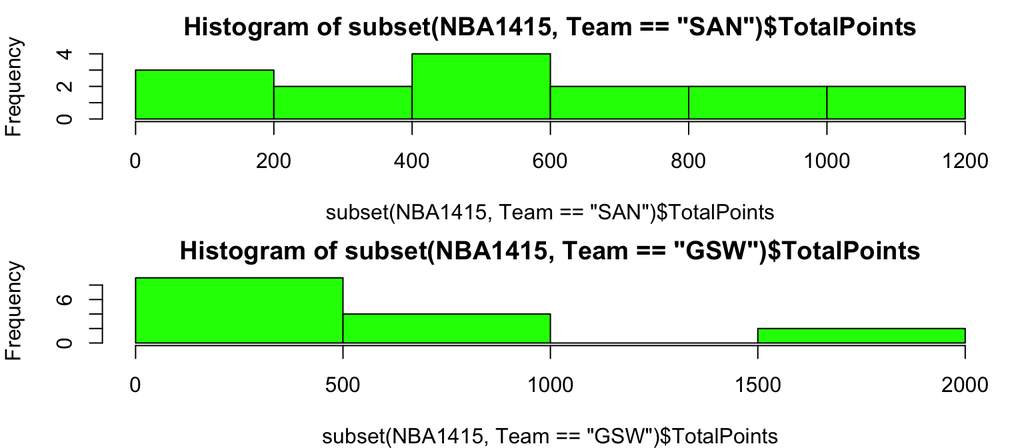

```r
par(mfrow = c(2, 1), mar = c(4, 4, 2, 1)) #一張圖裡面有2x1個子圖
hist(subset(NBA1415, Team == "SAN")$TotalPoints, col = "green")
hist(subset(NBA1415, Team == "GSW")$TotalPoints, col = "green")
```

## Scatterplot

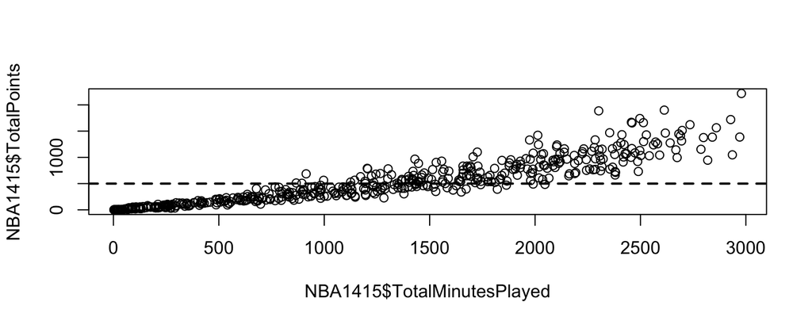

```r
par(mfrow = c(1, 1)) #一張圖裡面只有一個子圖
#畫x為TotalMinutesPlayed, y為TotalPoints的散佈圖
plot(NBA1415$TotalMinutesPlayed, NBA1415$TotalPoints)
#畫一條橫線h = 500，寬度lwd = 2，樣式lty = 2（虛線）
abline(h = 500, lwd = 2, lty = 2)
```

## Scatterplot - Using Color

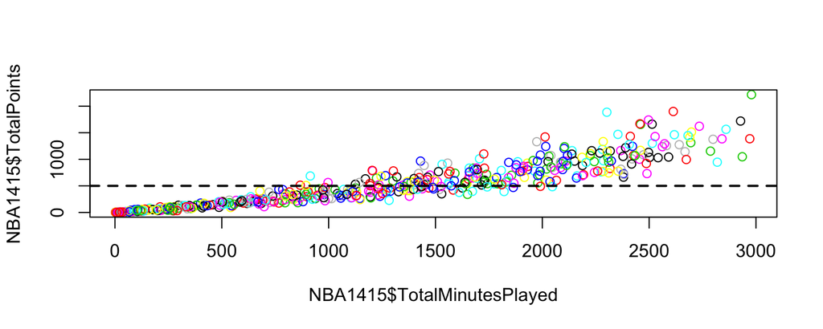

```r
#col=NBA1415$Team 用隊伍名稱著色，意指不同隊伍的球員不同色
plot(NBA1415$TotalMinutesPlayed, NBA1415$TotalPoints,col=NBA1415$Team)
abline(h = 500, lwd = 2, lty = 2)
```

## Multiple Scatterplots

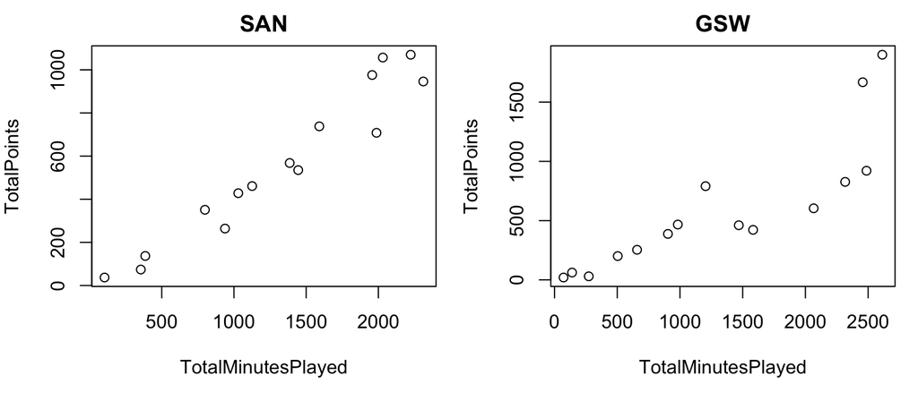

```r
par(mfrow = c(1, 2), mar = c(5, 4, 2, 1)) #一張圖裡面有1x2個子圖
with(subset(NBA1415, Team == "SAN"),
     plot(TotalMinutesPlayed, TotalPoints, main = "SAN"))
with(subset(NBA1415, Team == "GSW"),
     plot(TotalMinutesPlayed, TotalPoints, main = "GSW"))
```

## Summary

- Exploratory plots are "quick and dirty"
- Let you summarize the data (usually graphically) and highlight any broad features
- Explore basic questions and hypotheses (and perhaps rule them out)
- Suggest modeling strategies for the "next step"

## Further resources

- [R Graph Gallery](http://gallery.r-enthusiasts.com/)
- [R Graph Gallery](http://www.r-graph-gallery.com/all-graphs/)
- [R Bloggers](http://www.r-bloggers.com/)
- [Interactive visualizations with R](http://ouzor.github.io/blog/2014/11/21/interactive-visualizations.html)

## Plotting System -Lattice

## The Lattice Plotting System

包括以下Packaes:

- *lattice*: 包括畫圖相關的函數functions: `xyplot`, `bwplot`, `levelplot`
- *grid*: *lattice* package 的基礎
- 一個函數畫完圖，不能再加標記和文字等

## Lattice Functions

- `xyplot`: 畫散佈圖 scatterplots
- `bwplot`: 畫盒鬚圖box-and-whiskers plots (“boxplots”)
- `histogram`: 直方圖 histograms
- `stripplot`: 盒鬚圖＋點
- `dotplot`: dots on "violin strings"
- `splom`: 散佈圖的矩陣
- `levelplot`, `contourplot`: for plotting "image" data

## Lattice Functions

Lattice functions 通常第一個參數是 formula

```r
xyplot(y ~ x | f * g, data)
```

- We use the *formula notation* here, hence the `~`.
- `y~x`: y-axis~x-axis
- f,g are *conditioning variables* — optional
  - `*`: an interaction between two variables
- 第二個參數是資料`data`
- If no other arguments are passed, there are defaults that can be used.

## Simple Lattice Plot

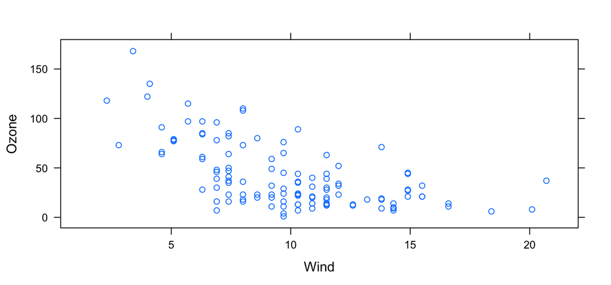

```r
library(lattice)
library(datasets)
## Simple scatterplot
xyplot(Ozone ~ Wind, data = airquality) # y~x
```